# Analysis of Swiss National Parks with Flickr data

Daniela Marino

5/2/2022

*Notes:* *Data: 2020-11-03_Switzerland_upto_2018-11-31, Switzerland_2018-12-01_2020-11-03.* *Pre-processing: After gathering the data, the two datasets were merged and it was cleaned the duplicates and empty values, specially for dates*

*PACKAGES*

### DATA LOADING

```r
#Data source
flickr <- read_xlsx(here("Flickr_Data.xlsx"), col_types = c("numeric", "text", "numeric",
        "numeric", "text", "date", "numeric",
        "text", "numeric", "text", "text",
        "text", "text", "text", "text", "text",
        "text"))# explore data

summary(flickr)
```

```
##     OBJECTID       photo_id              lat             lng
##  Min.   :    1   Length:82312       Min.   :45.90   Min.   : 6.073
##  1st Qu.:20579   Class :character   1st Qu.:46.47   1st Qu.: 6.998
##  Median :41157   Mode  :character   Median :46.63   Median : 7.138
##  Mean   :41157                      Mean   :46.75   Mean   : 7.605
##  3rd Qu.:61734                      3rd Qu.:47.07   3rd Qu.: 8.024
##  Max.   :82312                      Max.   :47.79   Max.   :10.492
##      USER                DATE                          USE
##  Length:82312       Min.   :1900-01-02 00:00:00   Min.   :100.0
##  Class :character   1st Qu.:2014-07-05 00:00:00   1st Qu.:120.0
##  Mode  :character   Median :2016-01-03 00:00:00   Median :220.0
##                     Mean   :2015-11-27 08:34:50   Mean   :228.4
##                     3rd Qu.:2017-12-19 06:00:00   3rd Qu.:300.0
##                     Max.   :2020-11-02 00:00:00   Max.   :420.0
##     CANTON               km2               TAGS              source
##  Length:82312       Min.   :  0.0033   Length:82312       Length:82312
##  Class :character   1st Qu.:293.6497   Class :character   Class :character
##  Mode  :character   Median :473.2996   Mode  :character   Mode  :character
##                     Mean   :436.6324
##                     3rd Qu.:632.1041
##                     Max.   :657.8204
##      PARK            Kategorie            Status           Inkraftset
##  Length:82312       Length:82312       Length:82312       Length:82312
##  Class :character   Class :character   Class :character   Class :character
##  Mode  :character   Mode  :character   Mode  :character   Mode  :character
##
##
##
##   Mutationsd         Mutationsg
##  Length:82312       Length:82312
##  Class :character   Class :character
##  Mode  :character   Mode  :character
##
##
##
```

```r
options(dplyr.summarise.inform = FALSE)
```

### FILTERING

#### a. Only pictures taken after 2004 (inclusive)

```r
# using subset function

flickr_04 <- as_tbl_time(flickr, index = DATE)

flickr_04 <- filter(flickr_04, DATE >= as.Date("2004-01-01"))

summary(flickr_04)
```

```
##     OBJECTID       photo_id              lat             lng
##  Min.   :    1   Length:81360       Min.   :45.90   Min.   : 6.073
##  1st Qu.:20586   Class :character   1st Qu.:46.47   1st Qu.: 6.998
##  Median :41082   Mode  :character   Median :46.63   Median : 7.138
##  Mean   :41113                      Mean   :46.75   Mean   : 7.604
##  3rd Qu.:61656                      3rd Qu.:47.08   3rd Qu.: 8.022
##  Max.   :82312                      Max.   :47.79   Max.   :10.492
##      USER                DATE                          USE
##  Length:81360       Min.   :2004-01-31 00:00:00   Min.   :100.0
##  Class :character   1st Qu.:2014-07-12 00:00:00   1st Qu.:120.0
##  Mode  :character   Median :2016-01-24 00:00:00   Median :220.0
##                     Mean   :2016-03-20 22:14:27   Mean   :228.8
##                     3rd Qu.:2017-12-31 00:00:00   3rd Qu.:300.0
##                     Max.   :2020-11-02 00:00:00   Max.   :420.0
##     CANTON               km2               TAGS              source
##  Length:81360       Min.   :  0.0033   Length:81360       Length:81360
##  Class :character   1st Qu.:293.6497   Class :character   Class :character
##  Mode  :character   Median :473.2996   Mode  :character   Mode  :character
##                     Mean   :435.9511
##                     3rd Qu.:632.1041
##                     Max.   :657.8204
##      PARK            Kategorie            Status           Inkraftset
##  Length:81360       Length:81360       Length:81360       Length:81360
##  Class :character   Class :character   Class :character   Class :character
##  Mode  :character   Mode  :character   Mode  :character   Mode  :character
##
##
##
##   Mutationsd         Mutationsg
##  Length:81360       Length:81360
##  Class :character   Class :character
##  Mode  :character   Mode  :character
##
##
##
```

#### b. Only pictures that are in categories of land cover that are natural

```r
flickr_04nat <- filter(flickr_04, USE!=100, USE!=120, USE!=140, USE!=160)

summary(flickr_04nat)
```

```
##     OBJECTID       photo_id              lat             lng
##  Min.   :    2   Length:54651       Min.   :45.98   Min.   : 6.073
##  1st Qu.:19231   Class :character   1st Qu.:46.47   1st Qu.: 7.000
##  Median :39129   Mode  :character   Median :46.62   Median : 7.172
##  Mean   :40353                      Mean   :46.73   Mean   : 7.663
##  3rd Qu.:61359                      3rd Qu.:47.08   3rd Qu.: 8.070
##  Max.   :82311                      Max.   :47.79   Max.   :10.492
##      USER                DATE                          USE
##  Length:54651       Min.   :2004-01-31 00:00:00   Min.   :200.0
##  Class :character   1st Qu.:2014-07-27 00:00:00   1st Qu.:220.0
##  Mode  :character   Median :2016-04-17 00:00:00   Median :240.0
##                     Mean   :2016-04-26 07:10:24   Mean   :285.2
##                     3rd Qu.:2018-05-20 00:00:00   3rd Qu.:300.0
##                     Max.   :2020-11-02 00:00:00   Max.   :420.0
##     CANTON               km2               TAGS              source
##  Length:54651       Min.   :  0.0033   Length:54651       Length:54651
##  Class :character   1st Qu.:276.5066   Class :character   Class :character
##  Mode  :character   Median :473.2996   Mode  :character   Mode  :character
##                     Mean   :425.8996
##                     3rd Qu.:632.1041
##                     Max.   :657.8204
##      PARK            Kategorie            Status           Inkraftset
##  Length:54651       Length:54651       Length:54651       Length:54651
##  Class :character   Class :character   Class :character   Class :character
##  Mode  :character   Mode  :character   Mode  :character   Mode  :character
##
##
##
##   Mutationsd         Mutationsg
##  Length:54651       Length:54651
##  Class :character   Class :character
##  Mode  :character   Mode  :character
##
##
##
```

## INTRODUCTION

```r
#Option 1 = Application of the filter of the use, only natural land cover

db <- flickr_04nat

ddbb <- db

#Option 2 = No application of the filter of the use, all land cover types

#ddbb <- flickr_04


#Option 3 = Using all dataset with no filters (after 2004 and land cover)

#ddbb <- flickr
```

*a. Number of visitors each Swiss National Parks, according the land cover,* *NA values refers to users or land cover category that doesn’t exist in the park*

```r
landcover <- flickr_04 %>%
  group_by(PARK, USE, USER)%>%
  summarise(land_user = n())

  #Counting the number of users per park in each season
landcover <- landcover %>%
  group_by(PARK, USE) %>%
  summarise(land = n())

lu<- pivot_wider(landcover, names_from = USE, values_from = land)
landcover_park <- as.data.frame(lu)

  #Rename of the codes (numbers) with the names of the days

    #Land cover categories that are reduced
names(landcover_park)[names(landcover_park)=="100"] <- "Building area"
names(landcover_park)[names(landcover_park)=="120"] <- "Traffic and transportation surface"
names(landcover_park)[names(landcover_park)=="140"] <- "Special settlement areas"
names(landcover_park)[names(landcover_park)=="160"] <- "Recreation and green spaces"

    #Land cover categories that are considered for the analysis
names(landcover_park)[names(landcover_park)=="200"] <- "Fruit growing, viticulture, horticulture"
names(landcover_park)[names(landcover_park)=="220"] <- "Arable and Forage Cultivation"
names(landcover_park)[names(landcover_park)=="240"] <- "Alpine farming"
names(landcover_park)[names(landcover_park)=="300"] <- "Forest"
names(landcover_park)[names(landcover_park)=="400"] <- "Lakes and rivers"
names(landcover_park)[names(landcover_park)=="420"] <- "Unproductives"

landcover_park <- landcover_park %>% arrange(PARK)
write.csv(landcover_park,"C:\\Users\\dmarinoc\\Documents\\GitHub\\Flickr_SwissParks\\LandCover.csv", row.names = FALSE)

  #Display of the table with a better format
kbl(landcover_park)%>%
  kable_styling(bootstrap_options = "striped", full_width = F, position = "left")
```

| PARK | Building area | Traffic and transportation surface | Special settlement areas | Recreation and green spaces | Fruit growing, viticulture, horticulture | Arable and Forage Cultivation | Alpine farming | Forest | Lakes and rivers | Unproductives |
| --- | --- | --- | --- | --- | --- | --- | --- | --- | --- | --- |
| Biosfera Val Müstair | 62 | 53 | 6 | 33 | 3 | 68 | 109 | 84 | 17 | 98 |
| Jurapark Aargau | 119 | 97 | 20 | 24 | 25 | 146 | NA | 85 | 38 | 7 |
| Landschaftspark Binntal | 29 | 23 | 4 | 1 | NA | 46 | 19 | 39 | 30 | 31 |
| Naturpark Beverin | 75 | 101 | 9 | 10 | 7 | 111 | 100 | 164 | 97 | 118 |
| Naturpark Diemtigtal | 15 | 9 | 1 | NA | 2 | 20 | 34 | 30 | 12 | 22 |
| Naturpark Gantrisch | 78 | 64 | 2 | 16 | 10 | 145 | 79 | 95 | 97 | 34 |
| Naturpark Pfyn-Finges | 112 | 55 | 18 | 24 | 25 | 72 | 95 | 71 | 51 | 148 |
| Naturpark Thal | 29 | 33 | 3 | 5 | 1 | 55 | 54 | 68 | 3 | 12 |
| Parc du Doubs | 133 | 80 | 10 | 17 | 8 | 112 | 70 | 143 | 112 | 30 |
| Parc Ela | 175 | 213 | 49 | 27 | 3 | 205 | 178 | 296 | 93 | 159 |
| Parc Jura vaudois | 172 | 125 | 27 | 68 | 10 | 168 | 203 | 182 | 99 | 42 |
| Parc naturel périurbain du Jorat | 3 | 5 | 1 | 2 | NA | 17 | NA | 34 | 7 | NA |
| Parc naturel régional de la Vallée du Trient | 107 | 102 | 37 | 13 | 26 | 63 | 96 | 195 | 80 | 249 |
| Parc naturel régional Gruyère Pays-d’Enhaut | 717 | 312 | 23 | 131 | 135 | 406 | 368 | 404 | 81 | 208 |
| Parc régional Chasseral | 121 | 121 | 18 | 31 | 36 | 144 | 160 | 133 | 5 | 14 |
| Parco Val Calanca | 7 | 4 | 1 | NA | 1 | 11 | 8 | 19 | 4 | 14 |
| Regionaler Naturpark Schaffhausen | 31 | 33 | 8 | 5 | 14 | 58 | 6 | 69 | 26 | 4 |
| Schweizerischer Nationalpark | 1 | NA | NA | 4 | NA | NA | 1 | 64 | 17 | 73 |
| UNESCO Biosphäre Entlebuch | 37 | 36 | 5 | 6 | 2 | 73 | 67 | 56 | 15 | 79 |
| Wildnispark Zürich Sihlwald | 5 | 15 | NA | NA | NA | 13 | NA | 42 | 11 | 5 |

*b. Area (km2) of national parks*

```r
area <- ddbb %>%
  group_by(PARK, km2) %>%
  summarise(flickr_feature = n())

  #Counting the total area of parks
area <- area %>%
  group_by(PARK) %>%
  summarise(km = round(sum(km2),2))

#The total area of parks:
area %>%
  summarize(area = sum(km))#km2
```

```
## # A tibble: 1 x 1
##    area
##   <dbl>
## 1 6018.
```

```r
summary(area)
```

```
##      PARK                 km
##  Length:20          Min.   :  9.38
##  Class :character   1st Qu.:158.43
##  Mode  :character   Median :285.08
##                     Mean   :300.90
##                     3rd Qu.:422.58
##                     Max.   :657.82
```

*c. Count of pictures in the parks*

```r
photos <- ddbb %>%
  group_by(PARK) %>%
  summarise(photo = n()) %>%
  mutate(ratio_photos= round((photo / sum(photo))*100, 3)) %>%
  arrange(desc(ratio_photos))

#The total number of pictures is:
ddbb %>%
  summarize(count =  n())#pictures
```

```
## # A tibble: 1 x 1
##   count
##   <int>
## 1 54651
```

```r
summary(photos)
```

```
##      PARK               photo          ratio_photos
##  Length:20          Min.   :  291.0   Min.   : 0.532
##  Class :character   1st Qu.:  881.5   1st Qu.: 1.613
##  Mode  :character   Median : 2042.5   Median : 3.737
##                     Mean   : 2732.6   Mean   : 5.000
##                     3rd Qu.: 3672.5   3rd Qu.: 6.720
##                     Max.   :11047.0   Max.   :20.214
```

*d. Count of Users in the parks*

```r
users_flickr <- ddbb %>%
  group_by(PARK, USER) %>%
  summarise(user_photos =  n())
  #Counting the total area of parks
users_flickr <- users_flickr %>%
  group_by(PARK) %>%
  summarise(user = n())%>%
  mutate(ratio_users= round((user / sum(user))*100, 3)) %>%
  arrange(desc(ratio_users))

#The total area of parks:
users_flickr %>%
  summarize(users = sum(user))#users
```

```
## # A tibble: 1 x 1
##   users
##   <int>
## 1  5022
```

```r
summary(users_flickr)
```

```
##      PARK                user        ratio_users
##  Length:20          Min.   : 31.0   Min.   : 0.617
##  Class :character   1st Qu.:105.5   1st Qu.: 2.101
##  Mode  :character   Median :209.5   Median : 4.171
##                     Mean   :251.1   Mean   : 5.000
##                     3rd Qu.:315.5   3rd Qu.: 6.282
##                     Max.   :943.0   Max.   :18.777
```

*d. Statistic of area (km2), users and photos for each Swiss National Parks:* *NOTE: THESE VALUES ONLY CONSIDER THE NATURAL LAND COVER (the dismissed categories are: Building area”, “Traffic and transportation surface”, “Special settlement areas”, “Recreation and green spaces”*

```r
general <- data.frame("Parks"= area$PARK, "km"= area$km, "Photos"= photos$photo, "Photos_per"= photos$ratio_photos, "Photos_km"=round((photos$photo/area$km),2),"Users"=users_flickr$user, "Users_per"=users_flickr$ratio_users, "Users_km"=round((users_flickr$user/area$km),2))

general <- general %>% arrange(Parks)

kbl(general) %>%
  kable_styling(bootstrap_options = "striped", full_width = F, position = "left")
```

[output not shown]

```r
write.csv(general,"C:\\Users\\dmarinoc\\Documents\\GitHub\\Flickr_SwissParks\\General.csv", row.names = FALSE)
```

## a. CONTRIBUTION OF USERS

```r
contrib <- ddbb %>%
  group_by(PARK, USER)%>%
  summarise(photo = n())
summary(contrib)
```

```
##      PARK               USER               photo
##  Length:5022        Length:5022        Min.   :   1.00
##  Class :character   Class :character   1st Qu.:   1.00
##  Mode  :character   Mode  :character   Median :   2.00
##                                        Mean   :  10.88
##                                        3rd Qu.:   7.00
##                                        Max.   :2631.00
```

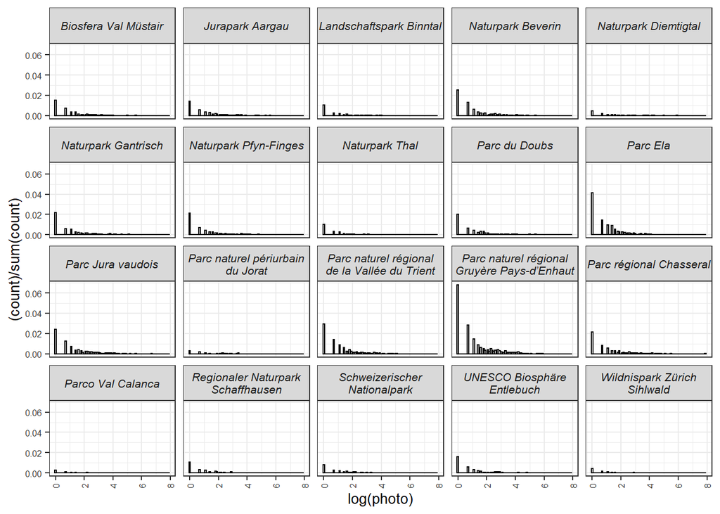

```r
ggplot(contrib, aes(x=log(photo))) +
  geom_histogram(aes(y=(..count..)/sum(..count..)),
                 binwidth = .1,
                 colour="black", fill="white")+
  facet_wrap(vars(PARK), labeller = label_wrap_gen(width=24))+
  theme_bw()+
  theme(axis.text.x = element_text(colour = "grey20", size = 6, angle = 90, hjust = 0.5, vjust = 0.5),
          axis.text.y = element_text(colour = "grey20", size = 6),
          strip.text = element_text(face = "italic"),
          text = element_text(size = 10))
```

```r
x <-contrib$photo
y <- x + rnorm(2500, 0, 50)
```

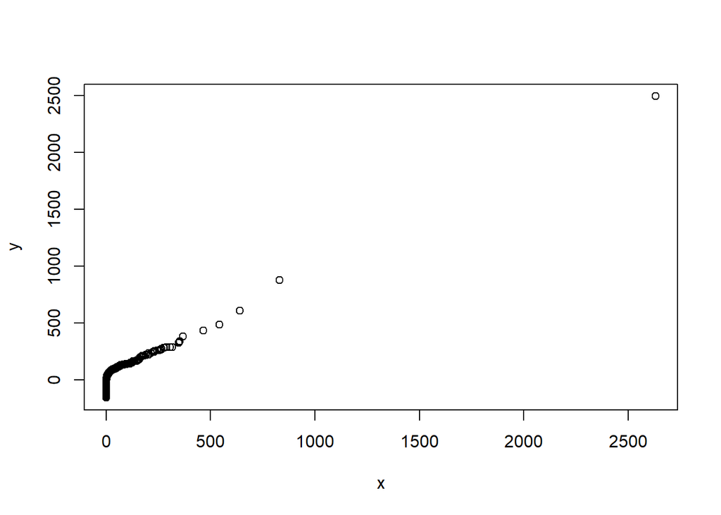

```r
qqplot(x, y)
```

## 1. YEARLY VISITOR IN THE PARKS

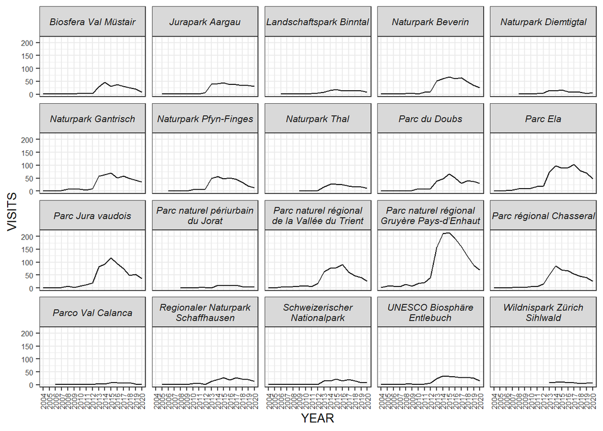

```r
ddbb$DATE <- as.Date(ddbb$DATE)
ddbb$YEAR <- format(ddbb$DATE, format="%Y")

#Calculation of statistics per year
year_photo <- ddbb %>%
  group_by(PARK, YEAR, USER)%>%
  summarise(photo_yearly = n())

yearly_counts <- year_photo %>%
  group_by(PARK, YEAR)%>%
  summarise(VISITS = n())

#png("C:\\Users\\dmarinoc\\Documents\\GitHub\\Flickr_SwissParks\\general_trend.png")

ggplot(data = yearly_counts, aes(x = YEAR, y = VISITS, group = 1)) +
    geom_line() +
    facet_wrap(vars(PARK), labeller = label_wrap_gen(width=24))+
    theme_bw()+
    theme(axis.text.x = element_text(colour = "grey20", size = 6, angle = 90, hjust = 0.5, vjust = 0.5),
          axis.text.y = element_text(colour = "grey20", size = 6),
          strip.text = element_text(face = "italic"),
          text = element_text(size = 10))
```

## 2. PARK USERS PER SEASON

*Number of users per season in each Swiss National Parks*

```r
#Creating season column

 #create dates variable for your column that contains dates
dates <- ddbb$DATE
#get the month of the date, create new column called month
ddbb$month<-(month(dates, label=TRUE))

ddbb$SEASON <- ifelse(ddbb$month %in% c('May','Jun','Jul'), "SUMMER",
                    ifelse (ddbb$month %in% c('Aug','Sep','Oct'), "AUTUMN",
                            ifelse (ddbb$month %in% c('Nove','Dec','Jan'),
                                    "WINTER", "SPRING")))

#Calculation of statistics per Season
season <- ddbb %>%
  group_by(PARK, SEASON, USER)%>%
  summarise(visit_season = n())

  #Counting the number of users per park in each season
season <- season %>%
  group_by(PARK, SEASON) %>%
  summarise(season_users = n())

sp<- pivot_wider(season, names_from = SEASON, values_from = season_users)
season_park <- data.frame(sp)
season_park <- season_park %>% arrange(PARK)

  #Display of the table with a better format
kbl(season_park)%>%
  kable_styling(bootstrap_options = "striped", full_width = F, position = "left")
```

| PARK | AUTUMN | SPRING | SUMMER | WINTER |
| --- | --- | --- | --- | --- |
| Biosfera Val Müstair | 118 | 22 | 83 | 12 |
| Jurapark Aargau | 91 | 84 | 99 | 34 |
| Landschaftspark Binntal | 58 | 11 | 38 | 6 |
| Naturpark Beverin | 174 | 60 | 147 | 35 |
| Naturpark Diemtigtal | 34 | 19 | 19 | 10 |
| Naturpark Gantrisch | 127 | 104 | 113 | 80 |
| Naturpark Pfyn-Finges | 138 | 60 | 102 | 26 |
| Naturpark Thal | 50 | 41 | 34 | 22 |
| Parc du Doubs | 122 | 75 | 107 | 42 |
| Parc Ela | 269 | 114 | 204 | 79 |
| Parc Jura vaudois | 191 | 156 | 159 | 100 |
| Parc naturel périurbain du Jorat | 19 | 18 | 12 | 11 |
| Parc naturel régional de la Vallée du Trient | 250 | 63 | 177 | 31 |
| Parc naturel régional Gruyère Pays-d’Enhaut | 419 | 236 | 407 | 179 |
| Parc régional Chasseral | 120 | 122 | 124 | 73 |
| Parco Val Calanca | 18 | 10 | 10 | 4 |
| Regionaler Naturpark Schaffhausen | 54 | 37 | 51 | 20 |
| Schweizerischer Nationalpark | 72 | 9 | 35 | 5 |
| UNESCO Biosphäre Entlebuch | 92 | 47 | 65 | 25 |
| Wildnispark Zürich Sihlwald | 11 | 19 | 23 | 11 |

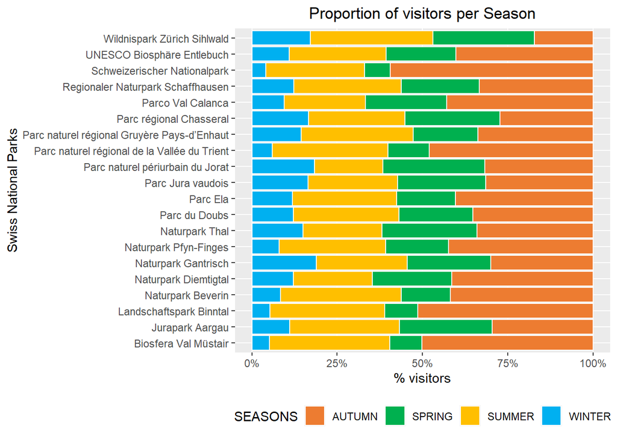

```r
  #Stacked normalized horizontal bar graph

#png("C:\\Users\\dmarinoc\\Documents\\GitHub\\Flickr_SwissParks\\season_park.png")

season_park %>% pivot_longer(-PARK) %>%
  ggplot(aes(x = factor(PARK), y = value, fill = name, group = name))+
  geom_bar(stat='identity', color='white', position='fill')+
  scale_y_continuous(labels = scales::percent)+
  scale_fill_manual(values=c("#ed7c31", "#00b04f", "#ffbf00","#00b0f0"))+
  theme(legend.position = 'bottom',
        panel.grid.minor = element_blank(),
        panel.border = element_blank(),
        plot.title = element_text(hjust=0.5))+
  coord_flip() +
  xlab('Swiss National Parks') + ylab('% visitors') +
  labs( fill = "SEASONS")+
  ggtitle('Proportion of visitors per Season')
```

## 3. PARK VISITORS PER DAY OF THE WEEK

*Number of visitors per day in each Swiss National Parks*

```r
ddbb$DAY <- weekdays(as.Date(ddbb$DATE))
ddbb$DAY <- factor(ddbb$DAY, levels = c("Monday","Tuesday","Wednesday","Thursday","Friday","Saturday","Sunday"))
#
photoUser_day <- ddbb %>%
  group_by(PARK, DAY, USER)%>%
  summarise(photo_day = n())

  #Counting the number of users per park in each season
daily <- photoUser_day %>%
  group_by(PARK, DAY) %>%
  summarise(visit_day = n())

sd<- pivot_wider(daily, names_from = DAY, values_from = visit_day)

daily_park <- as.data.frame(sd)
daily_park <- daily_park %>% arrange(PARK)

  #Display of the table with a better format
kbl(daily_park)%>%
  kable_styling(bootstrap_options = "striped", full_width = F, position = "left")
```

| PARK | Monday | Tuesday | Wednesday | Thursday | Friday | Saturday | Sunday |
| --- | --- | --- | --- | --- | --- | --- | --- |
| Biosfera Val Müstair | 39 | 44 | 43 | 40 | 36 | 55 | 53 |
| Jurapark Aargau | 46 | 33 | 45 | 47 | 48 | 68 | 65 |
| Landschaftspark Binntal | 18 | 20 | 16 | 16 | 19 | 26 | 25 |
| Naturpark Beverin | 58 | 63 | 62 | 63 | 60 | 98 | 109 |
| Naturpark Diemtigtal | 12 | 12 | 6 | 13 | 15 | 23 | 25 |
| Naturpark Gantrisch | 53 | 58 | 49 | 58 | 70 | 102 | 109 |
| Naturpark Pfyn-Finges | 55 | 49 | 52 | 39 | 48 | 96 | 87 |
| Naturpark Thal | 17 | 16 | 14 | 24 | 14 | 34 | 49 |
| Parc du Doubs | 44 | 40 | 40 | 43 | 49 | 92 | 98 |
| Parc Ela | 88 | 119 | 102 | 101 | 114 | 160 | 166 |
| Parc Jura vaudois | 87 | 71 | 84 | 85 | 93 | 148 | 171 |
| Parc naturel périurbain du Jorat | 10 | 8 | 13 | 4 | 7 | 12 | 11 |
| Parc naturel régional de la Vallée du Trient | 82 | 74 | 83 | 87 | 83 | 114 | 129 |
| Parc naturel régional Gruyère Pays-d’Enhaut | 161 | 148 | 152 | 168 | 170 | 327 | 309 |
| Parc régional Chasseral | 55 | 48 | 56 | 55 | 64 | 105 | 132 |
| Parco Val Calanca | 5 | 6 | 7 | 11 | 7 | 9 | 9 |
| Regionaler Naturpark Schaffhausen | 17 | 20 | 18 | 15 | 27 | 36 | 47 |
| Schweizerischer Nationalpark | 22 | 20 | 10 | 27 | 18 | 23 | 23 |
| UNESCO Biosphäre Entlebuch | 29 | 24 | 27 | 38 | 40 | 65 | 59 |
| Wildnispark Zürich Sihlwald | 12 | 4 | 7 | 6 | 6 | 19 | 15 |

```r
write.csv(daily_park,"C:\\Users\\dmarinoc\\Documents\\GitHub\\Flickr_SwissParks\\Daily_Park.csv", row.names = FALSE)
```

*Bar plot of visitors per day in the Parks*

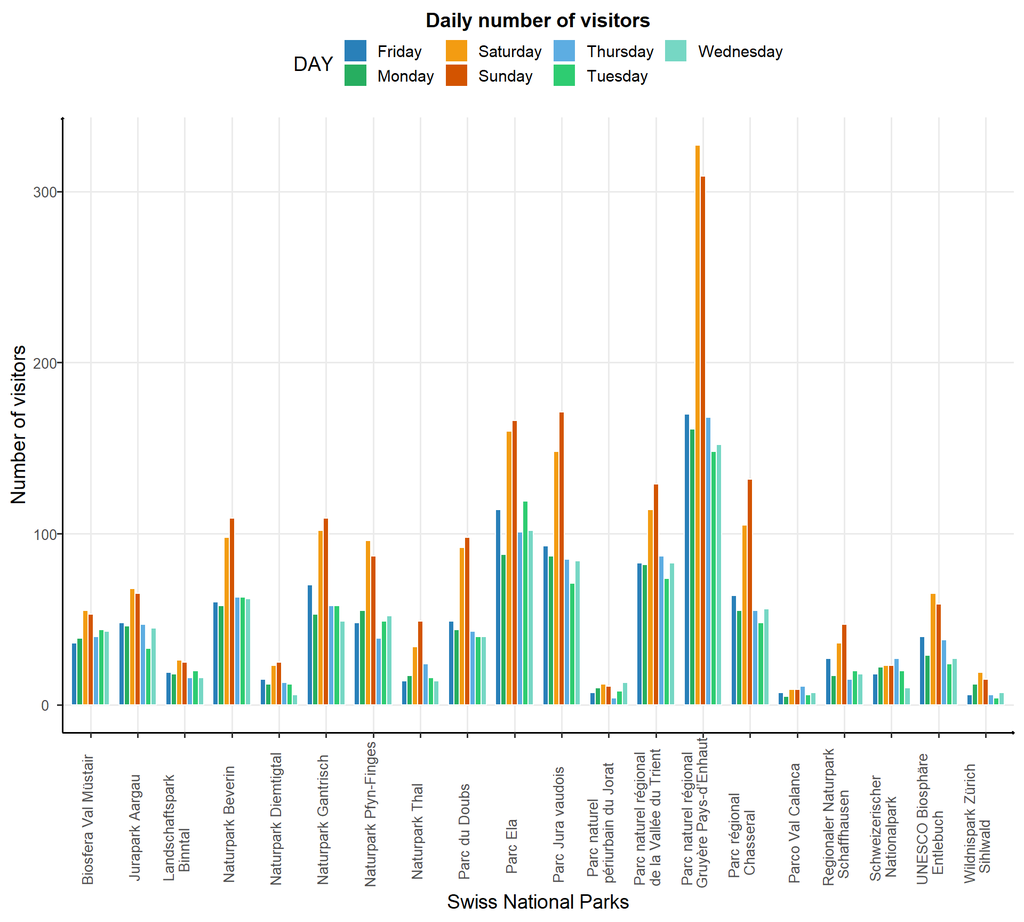

```r
  #Horizontal bar chart of daily number of visitors per Park

#png("C:\\Users\\dmarinoc\\Documents\\GitHub\\Flickr_SwissParks\\daily_park.png")

daily_park %>%
  pivot_longer(-PARK)  %>%
ggplot(aes(x = factor(PARK), y = value, fill = name, group = name)) +
  geom_bar(position="dodge", stat="identity", color='white', width = 0.8)+
  scale_fill_manual(values=c("#2980b9", "#27ae60", "#f39c12","#d35400", "#5dade2","#2ecc71","#76d7c4"))+
  theme_base()+
  scale_x_discrete(labels = function(x) str_wrap(x, width = 22))+
  xlab('Swiss National Parks') + ylab('Number of visitors') +
  labs( fill = "DAY")+
  ggtitle('Daily number of visitors')
```

*Mosaic plot of visitors per day in the Parks (Two test)*

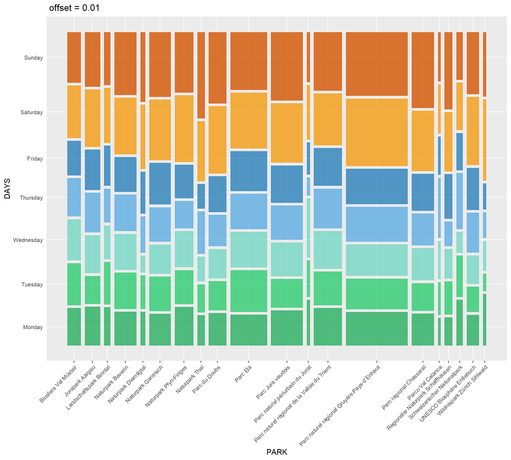

```r
  #GRAPH OF MOSAIC PLOT OF PARKS AND DAYS

#TEST 1:
#png("C:\\Users\\dmarinoc\\Documents\\GitHub\\Flickr_SwissParks\\daily_park_Mosaic1.png")

ggplot(data = photoUser_day) +
  geom_mosaic(aes(x=product(DAY, PARK), fill = DAY)) +
  scale_fill_manual(values=c("#27ae60","#2ecc71","#76d7c4", "#5dade2", "#2980b9", "#f39c12","#d35400"))+
  labs(y = "DAYS", title=" offset = 0.01") +
  theme(legend.position = "none",
        axis.text.y=element_text(size = 8),
        axis.ticks.y=element_blank(),
        axis.text.x = element_text(angle = 45, vjust = 1, hjust = 1, size = 8))
```

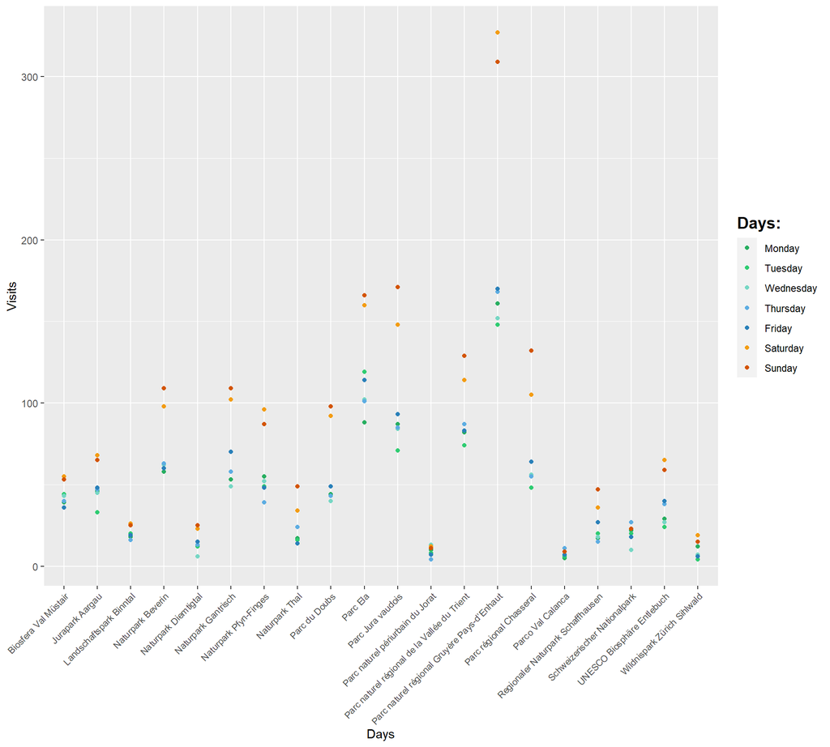

```r
#TEST 2:
#png("C:\\Users\\dmarinoc\\Documents\\GitHub\\Flickr_SwissParks\\daily_park_Mosaic2.png")

ggplot(daily, aes(x = PARK, y = visit_day, color = DAY)) +
  geom_point() +
  labs(x = "Days", y = "Visits") +
  scale_color_manual(name = "Days:", values=c("#27ae60","#2ecc71","#76d7c4", "#5dade2", "#2980b9", "#f39c12","#d35400")) +
  theme(legend.title = element_text(size = 14, face = 2),
        axis.text.x = element_text(angle = 45, vjust = 1, hjust = 1, size = 8))
```

## 5. USERS PROFILES

*Analysis of users according the canton origin, visited park, and time span between the first and the last picture*

### 5.a. Canton of origin

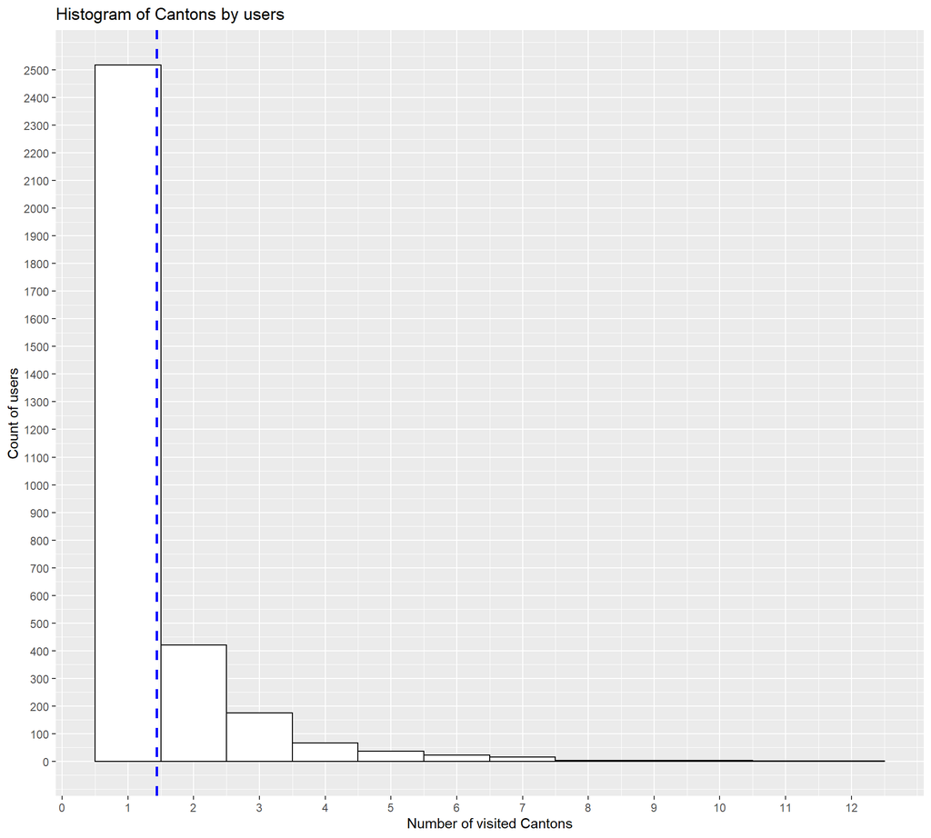

```r
canton<- ddbb %>%
  group_by(CANTON, USER)%>%
  summarise(canton_user = n())

co<- pivot_wider(canton, names_from = CANTON, values_from = canton_user)
canton_users <- as.data.frame(co)
canton_users[is.na(canton_users)] = 0
canton_users <- canton_users %>% mutate_if(is.numeric, ~1 * (. > 0))
canton_users$Total_Canton = rowSums(canton_users[,c(2:13)])
canton_users <- canton_users[order(canton_users$Total_Canton, decreasing = FALSE),]

write.csv(canton_users,"C:\\Users\\dmarinoc\\Documents\\GitHub\\Flickr_SwissParks\\Canton_Users.csv", row.names = FALSE)

ggplot(canton_users, aes(x=Total_Canton))+
  geom_histogram(binwidth=1 ,colour="black", fill="white")+
  geom_vline(aes(xintercept=mean(Total_Canton)), color="blue", linetype="dashed", size=1)+
  labs(title="Histogram of Cantons by users ",x="Number of visited Cantons", y = "Count of users")+
  scale_x_continuous(breaks = seq(0, 12, 1))+
  scale_y_continuous(breaks = seq(0, 2500, 100))
```

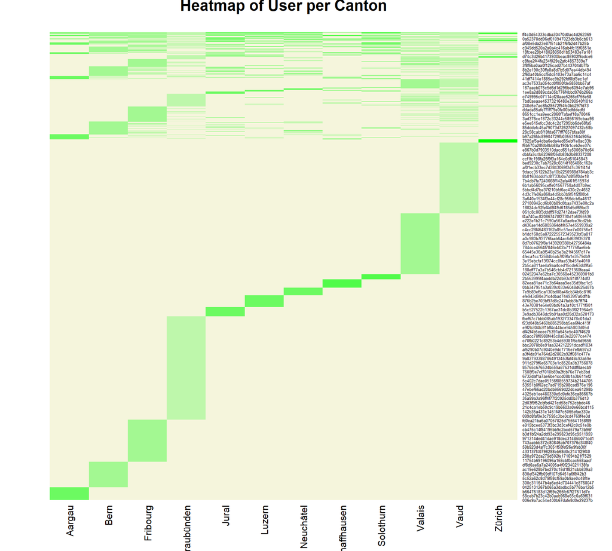

```r
#Heatmap

coul <- colorRampPalette(c("beige", "green"))(10)

rownames(canton_users) <- canton_users[,1]
canton_users[,1]<- NULL
canton_users[,13]<- NULL
data <-as.matrix(canton_users)

heatmap(data, Colv = NA, Rowv = NA, scale = "column", col = coul, main = "Heatmap of User per Canton")
```

```r
#Origin of user per Canton*
#kbl(canton_users[1:20,])%>%
#  kable_styling(bootstrap_options = "striped", full_width = F, #position = "left")
```

### 5.b. Park of origin

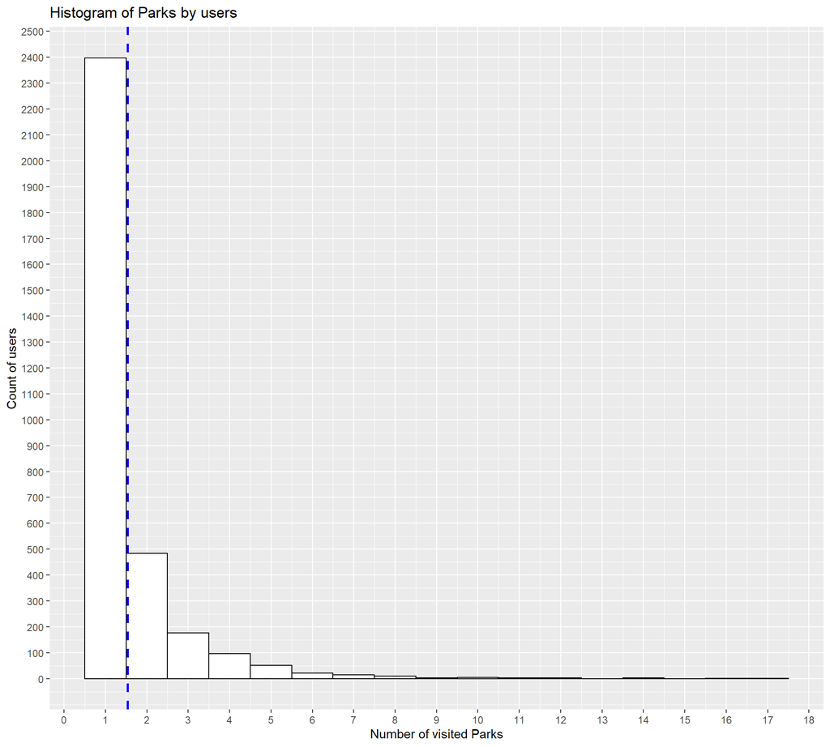

```r
park <- ddbb %>%
  group_by(PARK, USER)%>%
  summarise(park_user = n())

po<- pivot_wider(park, names_from = PARK, values_from = park_user)
park_users <- as.data.frame(po)
park_users[is.na(park_users)] = 0
park_users <- park_users %>% mutate_if(is.numeric, ~1 * (. > 0))
park_users$Total_Park = rowSums(park_users[,c(2:21)])
park_users <- park_users[order(park_users$Total_Park, decreasing = FALSE),]

write.csv(park_users,"C:\\Users\\dmarinoc\\Documents\\GitHub\\Flickr_SwissParks\\Park_Users.csv", row.names = FALSE)

ggplot(park_users, aes(x=Total_Park))+
  geom_histogram(binwidth=1 ,colour="black", fill="white")+
  geom_vline(aes(xintercept=mean(Total_Park)), color="blue", linetype="dashed", size=1)+
  labs(title="Histogram of Parks by users ",x="Number of visited Parks", y = "Count of users")+
  scale_x_continuous(breaks = seq(0, 20, 1))+
  scale_y_continuous(breaks = seq(0, 2500, 100))
```

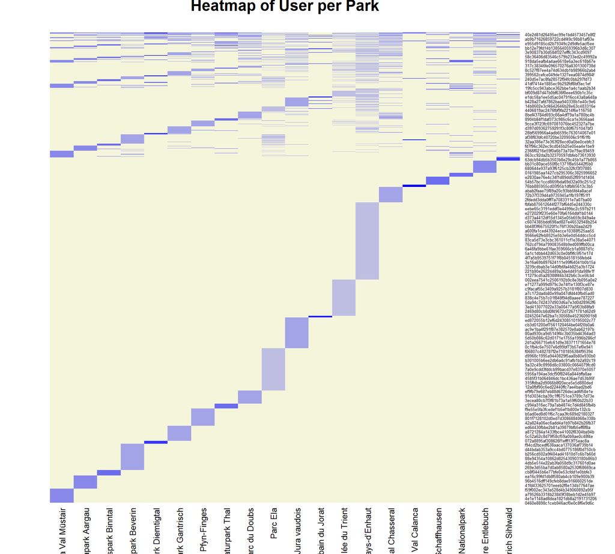

```r
#Heatmap

coul <- colorRampPalette(c("beige", "blue"))(10)

rownames(park_users) <- park_users[,1]
park_users[,1]<- NULL
park_users[,21]<- NULL
data <-as.matrix(park_users)

heatmap(data, Colv = NA, Rowv = NA, scale = "column", col = coul, main = "Heatmap of User per Park")
```

```r
#Origin of user per Park*
# kbl(park_users[1:20,])%>%
#  kable_styling(bootstrap_options = "striped", full_width = F, #position = "left")
```

### 5.c. Time span

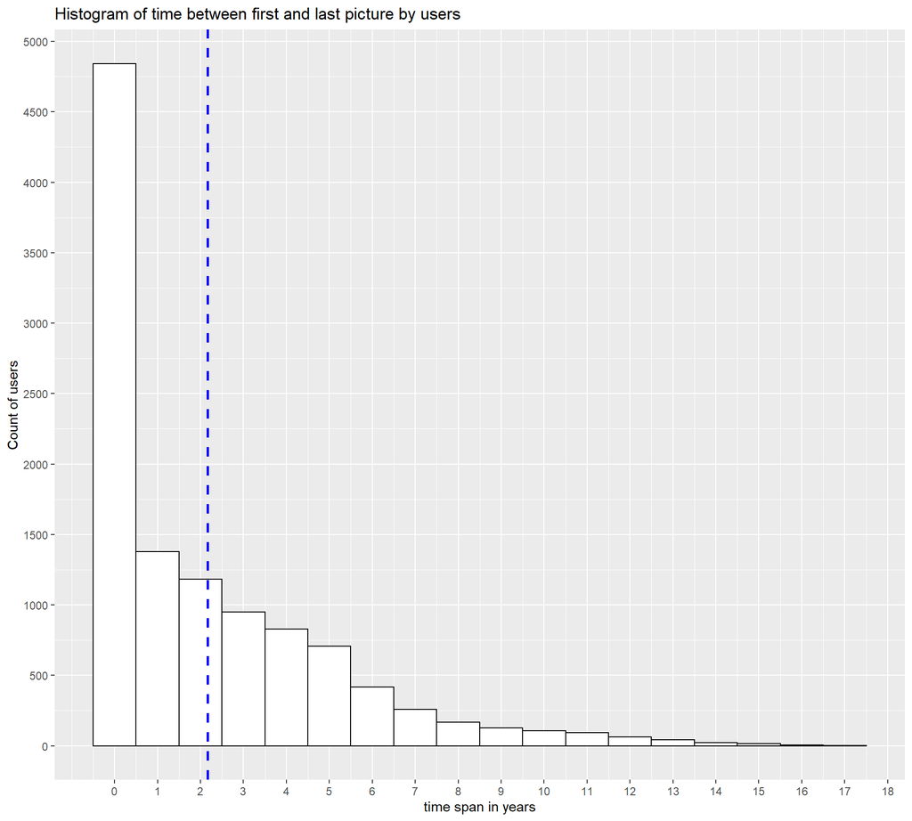

```r
user <- ddbb %>%
  group_by(USER)%>%
  summarise(photos = n())

user <- as.data.frame(user)

dt <- ddbb %>%
  group_by(USER, DATE)%>%
  summarise(photos = n())%>%
  mutate(DATE=as.Date(DATE))

dt1 <- dt %>%
    group_by(USER) %>%
    arrange(DATE) %>%
    slice(1L)

first <- as.data.frame(dt1)
names(first)[names(first)=="DATE"] <- "start"
dt2 <- dt %>%
    group_by(USER) %>%
     arrange(desc(DATE)) %>%
    slice(1L)

last <- as.data.frame(dt)
names(last)[names(last)=="DATE"] <- "end"
dt <- merge(last, first, by="USER")
dur <- dt %>%
  mutate(
    days = end - start,
    seconds    = as.numeric(difftime(end, start)) / 365.25,
    years = round((start %--% end) / years(1)),
    between = end %--% start
  )

time_user <-  merge(user, dur, by="USER", all=T)
time_user <- subset(time_user, select=-c(photos.x,photos.y))
time_user <- time_user[order(time_user$seconds, decreasing = TRUE),]

ggplot(time_user, aes(x=years))+
  geom_histogram(binwidth=1 ,colour="black", fill="white")+
  geom_vline(aes(xintercept=mean(years)), color="blue", linetype="dashed", size=1)+
  labs(title="Histogram of time between first and last picture by users ",x="time span in years", y = "Count of users")+
  scale_x_continuous(breaks = seq(0, 20, 1))+
  scale_y_continuous(breaks = seq(0, 5000, 500))
```

```r
write.csv(time_user,"C:\\Users\\dmarinoc\\Documents\\GitHub\\Flickr_SwissParks\\Time_Users.csv", row.names = FALSE)
```

```r
#User timespend of taken pictures
#kbl(time_user[1:20,])%>%
#  kable_styling(bootstrap_options = "striped", full_width = F, #position = "left")
```

*Photos taken in the same date in the same position*

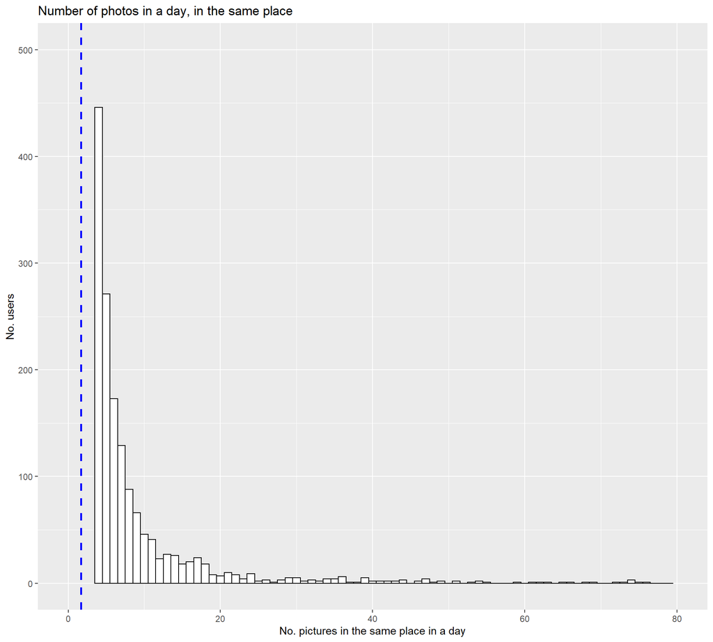

```r
  #5.d. Frequency of visits
photo_date_place <- ddbb %>%
  group_by(USER, DATE, lat)%>%
  summarise(photo1day_sameplace = n())

ggplot(photo_date_place, aes(x=photo1day_sameplace))+
  geom_histogram(binwidth=1 ,colour="black", fill="white")+
  geom_vline(aes(xintercept=mean(photo1day_sameplace)), color="blue", linetype="dashed", size=1)+
  labs(title="Number of photos in a day, in the same place ",x="No. pictures in the same place in a day", y = "No. users")+
  xlim(c(0,80))+ ylim(c(0,500))
```

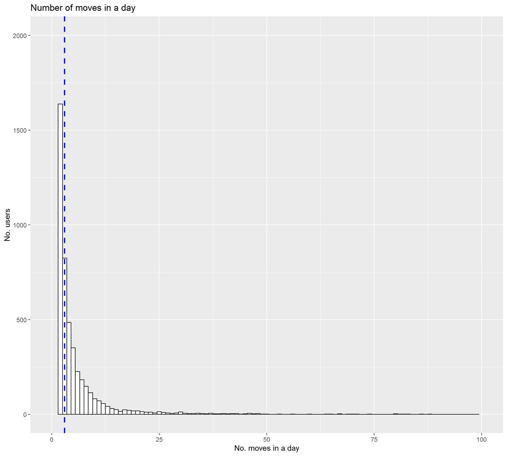

```r
user_date_place <- photo_date_place %>%
  group_by(USER, DATE)%>%
  summarise(moves1day_users= n())

ggplot(user_date_place, aes(x=moves1day_users))+
  geom_histogram(binwidth=1 ,colour="black", fill="white")+
  geom_vline(aes(xintercept=mean(moves1day_users)), color="blue", linetype="dashed", size=1)+
  labs(title="Number of moves in a day", x="No. moves in a day", y = "No. users")+
  xlim(c(0,100))+ ylim(c(0,2000))
```

*Presence of visitors in a day, in different positions*

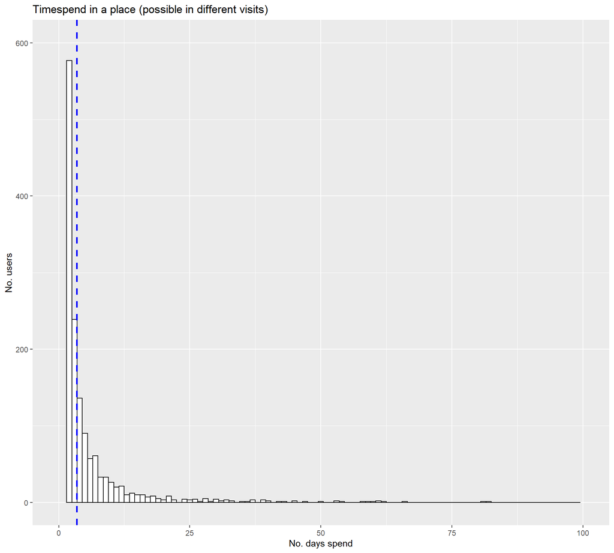

```r
user_daily_visits <- user_date_place %>%
  group_by(USER)%>%
  summarise(user_day_stay = n())

ggplot(user_daily_visits, aes(x=user_day_stay))+
  geom_histogram(binwidth=1 ,colour="black", fill="white")+
  geom_vline(aes(xintercept=mean(user_day_stay)), color="blue", linetype="dashed", size=1)+
  labs(title="Timespend in a place (possible in different visits)", x="No. days spend", y = "No. users")+
  xlim(c(0,100))+ ylim(c(0,600))
```

## Textual Analysis

[figure not shown]

```r
set.seed(42)

base <- data.frame(ddbb$photo_id, ddbb$USER, ddbb$PARK,  ddbb$TAGS)
names(base)[names(base) == "ddbb.PARK"] <- "doc_id"
names(base)[names(base) == "ddbb.TAGS"] <- "text"
names(base)[names(base) == "ddbb.USER"] <- "author"
names(base)[names(base) == "ddbb.photo_id"] <- "origin"
base$text <- tolower(base$text) # Lowercase
base$text <- gsub("[[:digit:]]", " ", base$text) # Remove numbers
base$text <- gsub("\\s+", " ", str_trim(base$text)) # Remove extra whitespaces
base$text <- gsub("(\\-¨“„)", " ", base$text) # Remove extra symbols
base$text <- gsub("(?!\\.)[[:punct:]]", " ", base$text, perl=TRUE) #remove punctuation
base <- base[-which(is.na(base$text)),] #dropping row without TAGS
base_source=DataframeSource(base)
base_corpus=VCorpus(base_source)
base_corpus_clean <- tm_map(base_corpus, removeWords, stopwords("english"))
base_corpus_root <- tm_map(base_corpus_clean,stemDocument) #find to root of the words
wordcloud(base_corpus_root,
          min.freq = 50,
          max.words = 100,
          random.order = FALSE,
          random.color = FALSE,
          colors = brewer.pal(8, "Dark2"))
```

```r
#myStopwords <- setdiff(myStopwords, c("d", "e"))
#text_corpus_clean <- tm_map(base_corpus_clean, removeWords, myStopwords)

dtm <- DocumentTermMatrix(base_corpus_root, control= list(wordLengths=c(3, 8)))
head(sort(slam::col_sums(dtm), decreasing = TRUE), n=10)
```

```
##    suiss  schweiz mountain     jura      alp   vision    natur svizzera
##    11529    10725     5336     4026     3873     3441     3395     3321
## landscap     ride
##     2902     2596
```

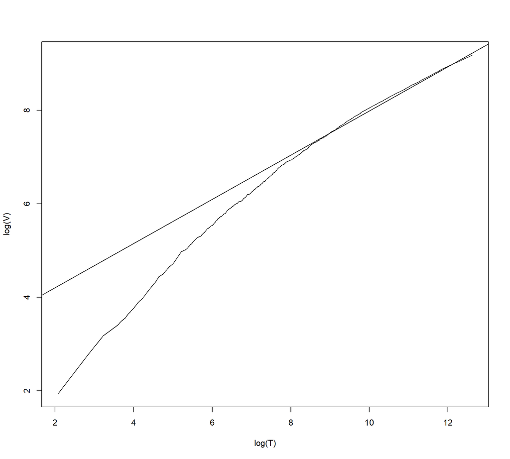

```
## (Intercept)           x
##   3.2629802   0.4723514
```

```r
Heaps_plot(dtm)
```

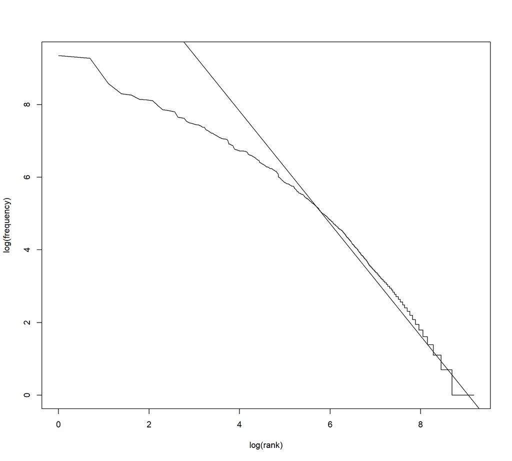

```
## (Intercept)           x
##   14.015529   -1.548751
```

```r
Zipf_plot(dtm)
```

*Bipartite network of parks and tags*

```r
dtm_df <- reshape2::melt(as.matrix(dtm))
# remove 0 values and order the data.frame
dtm_df <- dtm_df[dtm_df$value > 2, ]
dtm_df <- dtm_df[order(dtm_df$value, decreasing = TRUE), ]
```

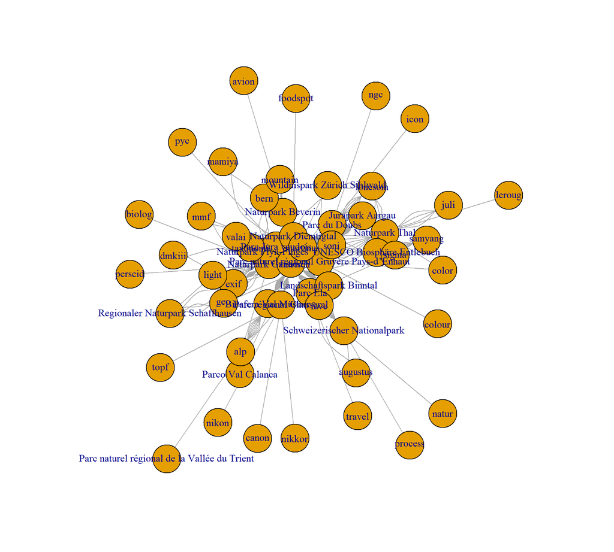

```r
set.seed(42)
g <- graph.data.frame(dtm_df, directed = FALSE)
#bg <-bipartite.mapping(g)
plot(g)
```